# DATA 606-Introduction to Linear Regression

Anthony Conrardy

The Human Freedom Index is a report that attempts to summarize the idea of “freedom” through a bunch of different variables for many countries around the globe. It serves as a rough objective measure for the relationships between the different types of freedom - whether it’s political, religious, economical or personal freedom - and other social and economic circumstances. The Human Freedom Index is an annually co-published report by the Cato Institute, the Fraser Institute, and the Liberales Institut at the Friedrich Naumann Foundation for Freedom.

In this lab, you’ll be analyzing data from Human Freedom Index reports from 2008-2016. Your aim will be to summarize a few of the relationships within the data both graphically and numerically in order to find which variables can help tell a story about freedom.

## Getting Started

### Load packages

In this lab, you will explore and visualize the data using the **tidyverse** suite of packages. The data can be found in the companion package for OpenIntro resources, **openintro**.

Let’s load the packages.

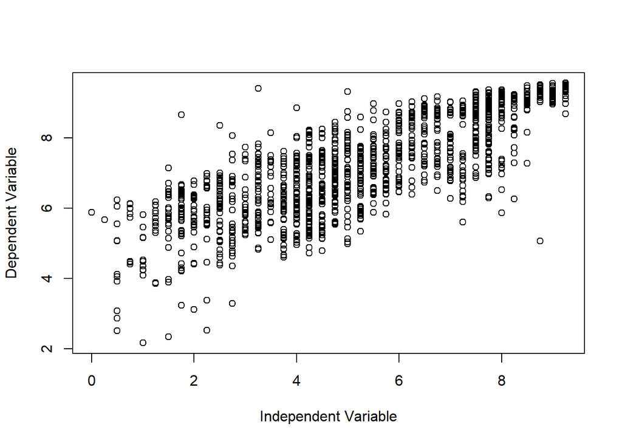

```r
library(tidyverse)
library(openintro)
data('hfi', package='openintro')
plot(pf_score ~ pf_expression_control, hfi,
     xlab = "Independent Variable", ylab = "Dependent Variable")
```

### The data

The data we’re working with is in the openintro package and it’s called `hfi`, short for Human Freedom Index.

1. What are the dimensions of the dataset?

**This data set is comprised of 123 variables (columns) and 1458 observations (rows).**

2. What type of plot would you use to display the relationship between the personal freedom score, `pf_score`, and one of the other numerical variables? Plot this relationship using the variable `pf_expression_control` as the predictor. Does the relationship look linear? If you knew a country’s `pf_expression_control`, or its score out of 10, with 0 being the most, of political pressures and controls on media content, would you be comfortable using a linear model to predict the personal freedom score?

**A simple scatterplot would be sufficient to determine if a linear relationship is readily evident. While the pf_score (dependent variable) is more continuous in nature, the pf_expression_control (independent variable) is more discrete. However, there does appear to be a positive linear relationship between the two variables.**

If the relationship looks linear, we can quantify the strength of the relationship with the correlation coefficient.

```r
hfi %>%
  summarise(cor(pf_expression_control, pf_score, use = "complete.obs"))
```

```
## # A tibble: 1 × 1
##   `cor(pf_expression_control, pf_score, use = "complete.obs")`
##                                                          <dbl>
## 1                                                        0.796
```

Here, we set the `use` argument to “complete.obs” since there are some observations of NA.

## Sum of squared residuals

In this section, you will use an interactive function to investigate what we mean by “sum of squared residuals”. You will need to run this function in your console, not in your markdown document. Running the function also requires that the `hfi` dataset is loaded in your environment.

Think back to the way that we described the distribution of a single variable. Recall that we discussed characteristics such as center, spread, and shape. It’s also useful to be able to describe the relationship of two numerical variables, such as `pf_expression_control` and `pf_score` above.

3. Looking at your plot from the previous exercise, describe the relationship between these two variables. Make sure to discuss the form, direction, and strength of the relationship as well as any unusual observations.

Just as you’ve used the mean and standard deviation to summarize a single variable, you can summarize the relationship between these two variables by finding the line that best follows their association. Use the following interactive function to select the line that you think does the best job of going through the cloud of points.

```r
# This will only work interactively (i.e. will not show in the knitted document)
hfi <- hfi %>% filter(complete.cases(pf_expression_control, pf_score))
DATA606::plot_ss(x = hfi$pf_expression_control, y = hfi$pf_score)
```

$$e_i = y_i - \hat{y}_i$$

The most common way to do linear regression is to select the line that minimizes the sum of squared residuals. To visualize the squared residuals, you can rerun the plot command and add the argument `showSquares = TRUE`.

```r
DATA606::plot_ss(x = hfi$pf_expression_control, y = hfi$pf_score, showSquares = TRUE)
```

Note that the output from the `plot_ss` function provides you with the slope and intercept of your line as well as the sum of squares.

4. Using `plot_ss`, choose a line that does a good job of minimizing the sum of squares. Run the function several times. What was the smallest sum of squares that you got? How does it compare to your neighbors?

**The smallest SS I got was 963.07, while most of the others were over 1000. I noticed that if you selected points more in the middle of the plot it gave a better estimation of the SS.**

## The linear model

It is rather cumbersome to try to get the correct least squares line, i.e. the line that minimizes the sum of squared residuals, through trial and error. Instead, you can use the `lm` function in R to fit the linear model (a.k.a. regression line).

```r
m1 <- lm(pf_score ~ pf_expression_control, data = hfi)
```

The first argument in the function `lm` is a formula that takes the form `y ~ x`. Here it can be read that we want to make a linear model of `pf_score` as a function of `pf_expression_control`. The second argument specifies that R should look in the `hfi` data frame to find the two variables.

The output of `lm` is an object that contains all of the information we need about the linear model that was just fit. We can access this information using the summary function.

```r
summary(m1)
```

```
##
## Call:
## lm(formula = pf_score ~ pf_expression_control, data = hfi)
##
## Residuals:
##     Min      1Q  Median      3Q     Max
## -3.8467 -0.5704  0.1452  0.6066  3.2060
##
## Coefficients:
##                       Estimate Std. Error t value Pr(>|t|)
## (Intercept)            4.61707    0.05745   80.36   <2e-16 ***
## pf_expression_control  0.49143    0.01006   48.85   <2e-16 ***
## ---
## Signif. codes:  0 '***' 0.001 '**' 0.01 '*' 0.05 '.' 0.1 ' ' 1
##
## Residual standard error: 0.8318 on 1376 degrees of freedom
##   (80 observations deleted due to missingness)
## Multiple R-squared:  0.6342, Adjusted R-squared:  0.634
## F-statistic:  2386 on 1 and 1376 DF,  p-value: < 2.2e-16
```

Let’s consider this output piece by piece. First, the formula used to describe the model is shown at the top. After the formula you find the five-number summary of the residuals. The “Coefficients” table shown next is key; its first column displays the linear model’s y-intercept and the coefficient of `pf_expression_control`. With this table, we can write down the least squares regression line for the linear model:

$$\hat{y} = 4.61707 + 0.49143 \times pf\_expression\_control$$

5. Fit a new model that uses `pf_expression_control` to predict `hf_score`, or the total human freedom score. Using the estimates from the R output, write the equation of the regression line. What does the slope tell us in the context of the relationship between human freedom and the amount of political pressure on media content?

```r
m2 <- lm(hf_score ~ pf_expression_control, data = hfi)
summary(m2)
```

```
##
## Call:
## lm(formula = hf_score ~ pf_expression_control, data = hfi)
##
## Residuals:
##     Min      1Q  Median      3Q     Max
## -2.6198 -0.4908  0.1031  0.4703  2.2933
##
## Coefficients:
##                       Estimate Std. Error t value Pr(>|t|)
## (Intercept)           5.153687   0.046070  111.87   <2e-16 ***
## pf_expression_control 0.349862   0.008067   43.37   <2e-16 ***
## ---
## Signif. codes:  0 '***' 0.001 '**' 0.01 '*' 0.05 '.' 0.1 ' ' 1
##
## Residual standard error: 0.667 on 1376 degrees of freedom
##   (80 observations deleted due to missingness)
## Multiple R-squared:  0.5775, Adjusted R-squared:  0.5772
## F-statistic:  1881 on 1 and 1376 DF,  p-value: < 2.2e-16
```

**The equation for the regression line is:**
$$\hat{y} = 5.153687 + 0.349862 \times pf\_expression\_control$$
**The slope of the regression lines is less as compared to that of the regression involving Personal Freedom, there is still a positive correlation between the predictor and dependent variables. However, in this case, the model only accounts for about 58% (0.5772) of the variance of the dependent variable.**

## Prediction and prediction errors

Let’s create a scatterplot with the least squares line for `m1` laid on top.

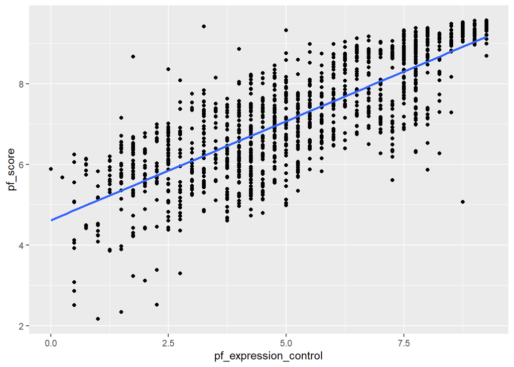

```r
ggplot(data = hfi, aes(x = pf_expression_control, y = pf_score)) +
  geom_point() +
  stat_smooth(method = "lm", se = FALSE)
```

Here, we are literally adding a layer on top of our plot. `geom_smooth` creates the line by fitting a linear model. It can also show us the standard error `se` associated with our line, but we’ll suppress that for now.

This line can be used to predict $y$ at any value of $x$. When predictions are made for values of $x$ that are beyond the range of the observed data, it is referred to as *extrapolation* and is not usually recommended. However, predictions made within the range of the data are more reliable. They’re also used to compute the residuals.

6. If someone saw the least squares regression line and not the actual data, how would they predict a country’s personal freedom score for one with a 6.7 rating for `pf_expression_control`? Is this an overestimate or an underestimate, and by how much? In other words, what is the residual for this prediction?

## Model diagnostics

To assess whether the linear model is reliable, we need to check for (1) linearity, (2) nearly normal residuals, and (3) constant variability.

**Linearity**: You already checked if the relationship between `pf_score` and `pf_expression_control’ is linear using a scatterplot. We should also verify this condition with a plot of the residuals vs. fitted (predicted) values.

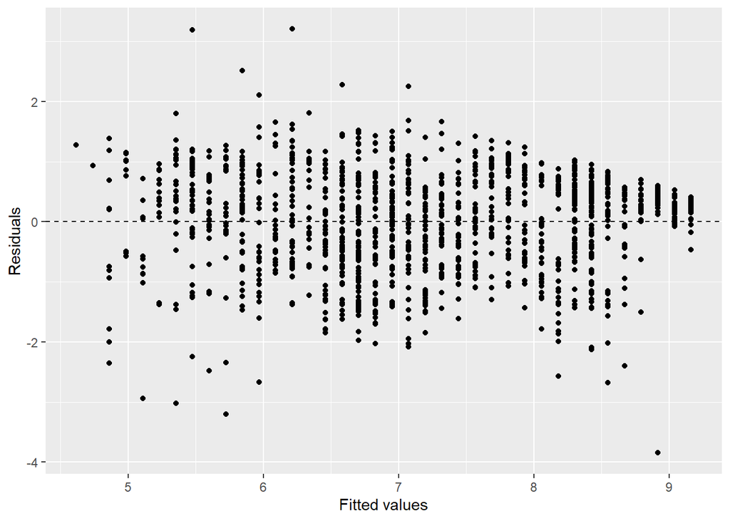

```r
ggplot(data = m1, aes(x = .fitted, y = .resid)) +
  geom_point() +
  geom_hline(yintercept = 0, linetype = "dashed") +
  xlab("Fitted values") +
  ylab("Residuals")
```

Notice here that `m1` can also serve as a data set because stored within it are the fitted values ($\hat{y}$) and the residuals. Also note that we’re getting fancy with the code here. After creating the scatterplot on the first layer (first line of code), we overlay a horizontal dashed line at $y = 0$ (to help us check whether residuals are distributed around 0), and we also rename the axis labels to be more informative.

7. Is there any apparent pattern in the residuals plot? What does this indicate about the linearity of the relationship between the two variables?

**There does not seem to be a noticeable pattern to the residual and they appear to random around 0. However, we can definitely discern some outliers that we might want to investigate. That being said, it appears that the plot indicates a linear relationship between the two variables.**

**Nearly normal residuals**: To check this condition, we can look at a histogram

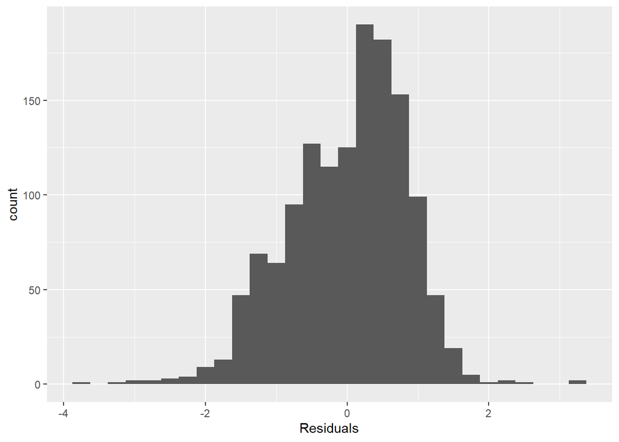

```r
ggplot(data = m1, aes(x = .resid)) +
  geom_histogram(binwidth = 0.25) +
  xlab("Residuals")
```

or a normal probability plot of the residuals.

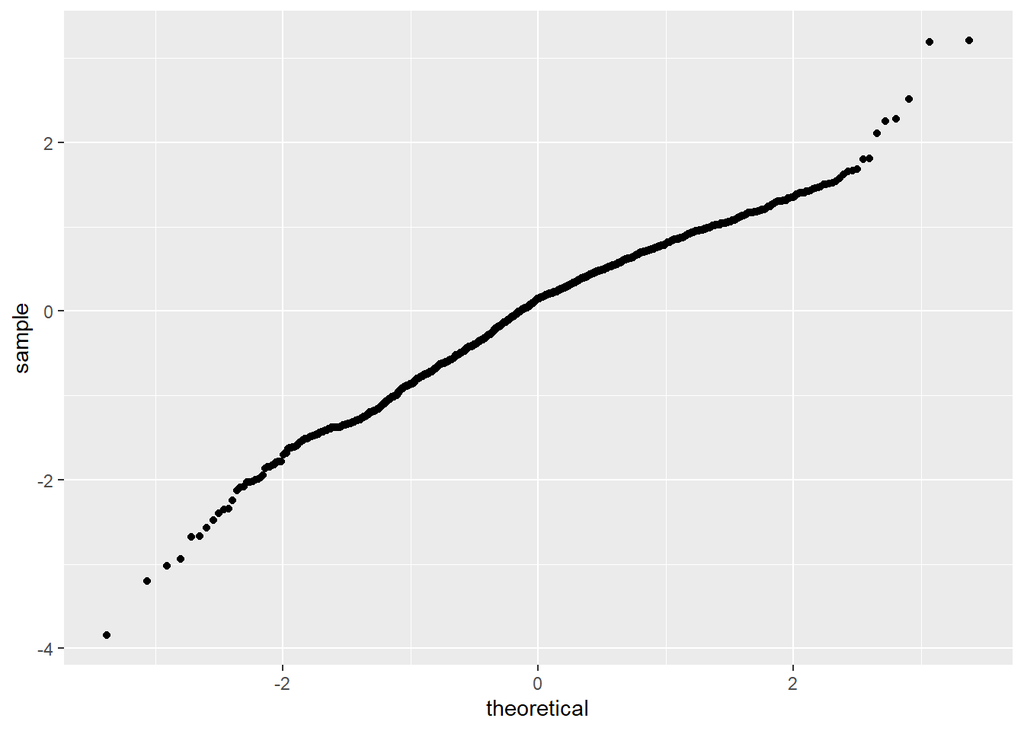

```r
ggplot(data = m1, aes(sample = .resid)) +
  stat_qq()
```

Note that the syntax for making a normal probability plot is a bit different than what you’re used to seeing: we set `sample` equal to the residuals instead of `x`, and we set a statistical method `qq`, which stands for “quantile-quantile”, another name commonly used for normal probability plots.

8. Based on the histogram and the normal probability plot, does the nearly normal residuals condition appear to be met?

**Though the residual histogram appears to be slightly left skewed, and the qq plot has extreme variances at the beginning and end, it does appear that the normal residuals condition to be met.**

**Constant variability**:

9. Based on the residuals vs. fitted plot, does the constant variability condition appear to be met?

**Yes, based upon the residuals vs. fitted plot the constant variance condition appears to be met and the models predictions are reliable across the range of independent variables, though some outliers exist that we would like to investigate.**

## More Practice

- Choose another freedom variable and a variable you think would strongly correlate with it.. Produce a scatterplot of the two variables and fit a linear model. At a glance, does there seem to be a linear relationship?

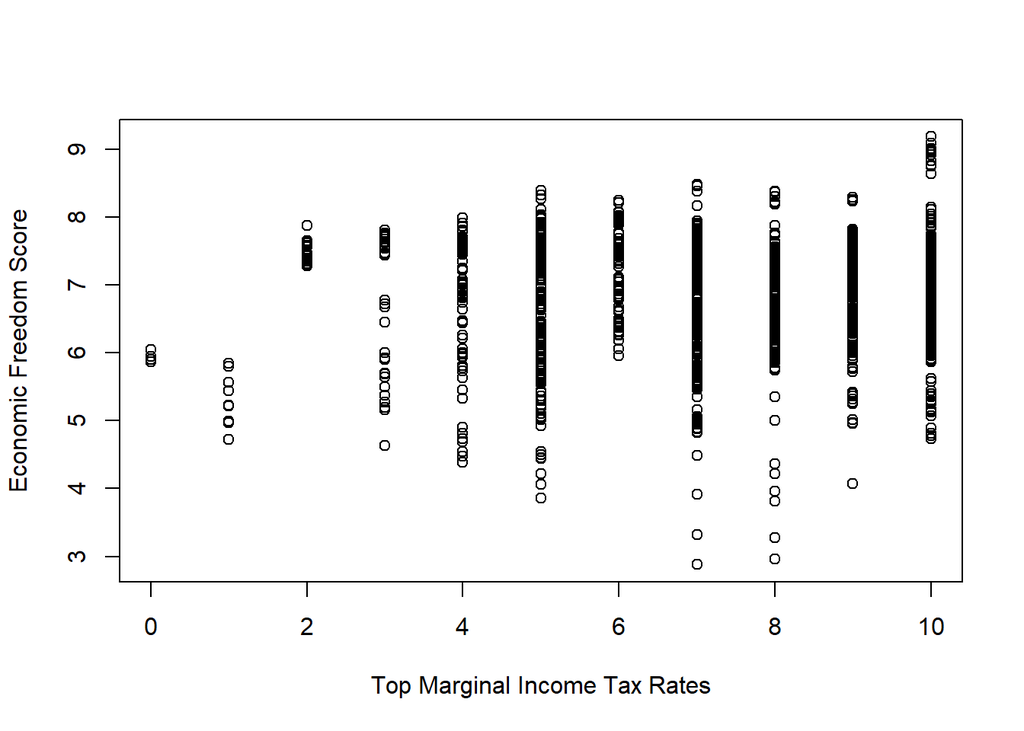

```r
##ef_score and ef_government_tax_income
plot(ef_score ~  ef_government_tax_income, hfi,
     xlab = "Top Marginal Income Tax Rates", ylab = "Economic Freedom Score")
```

**For this exercise, I selected the Top Marginal Income Tax Rates as a predictor of economic freedom score. This was based upon the premise that higher tax rates would result in lower economic freedom. At first glance, there does not appear to be an obvious linear relationship.**

- How does this relationship compare to the relationship between `pf_expression_control` and `pf_score`? Use the $R^2$ values from the two model summaries to compare. Does your independent variable seem to predict your dependent one better? Why or why not?

```r
m4 <- lm(ef_score ~  ef_government_tax_income, data = hfi)
summary(m4)
```

```
##
## Call:
## lm(formula = ef_score ~ ef_government_tax_income, data = hfi)
##
## Residuals:
##     Min      1Q  Median      3Q     Max
## -3.9165 -0.5089  0.0907  0.6010  2.2503
##
## Coefficients:
##                          Estimate Std. Error t value Pr(>|t|)
## (Intercept)               6.46241    0.07982  80.961  < 2e-16 ***
## ef_government_tax_income  0.04773    0.01029   4.641 3.82e-06 ***
## ---
## Signif. codes:  0 '***' 0.001 '**' 0.01 '*' 0.05 '.' 0.1 ' ' 1
##
## Residual standard error: 0.8663 on 1332 degrees of freedom
##   (124 observations deleted due to missingness)
## Multiple R-squared:  0.01591,    Adjusted R-squared:  0.01517
## F-statistic: 21.54 on 1 and 1332 DF,  p-value: 3.815e-06
```

**This model is horrible as it compares to the model that was used in early part of this lab. For every unit increase in the Top Marginal Income Tax Rates, we less than 0.05 (0.04773) increase in the economic freedom score, and the model accounts for less than 2% (0.01591) of the variance in the dependent variable (EF_score). This was a very poor model.**

- What’s one freedom relationship you were most surprised about and why? Display the model diagnostics for the regression model analyzing this relationship.

**I was very surprised at the model above, you would think that higher tax rates would result in less economic freedom but that did not seem to be the case. But, I decided to see if the higher tax rates impacted personal freedom score in some way, so I ran that model also.**

```r
m5 <- lm(pf_score ~  ef_government_tax_income, data = hfi)
summary(m5)
```

```
##
## Call:
## lm(formula = pf_score ~ ef_government_tax_income, data = hfi)
##
## Residuals:
##     Min      1Q  Median      3Q     Max
## -4.7078 -0.9385  0.0258  1.2258  2.3264
##
## Coefficients:
##                          Estimate Std. Error t value Pr(>|t|)
## (Intercept)                8.2295     0.1241  66.285   <2e-16 ***
## ef_government_tax_income  -0.1355     0.0160  -8.471   <2e-16 ***
## ---
## Signif. codes:  0 '***' 0.001 '**' 0.01 '*' 0.05 '.' 0.1 ' ' 1
##
## Residual standard error: 1.348 on 1332 degrees of freedom
##   (124 observations deleted due to missingness)
## Multiple R-squared:  0.05112,    Adjusted R-squared:  0.0504
## F-statistic: 71.75 on 1 and 1332 DF,  p-value: < 2.2e-16
```

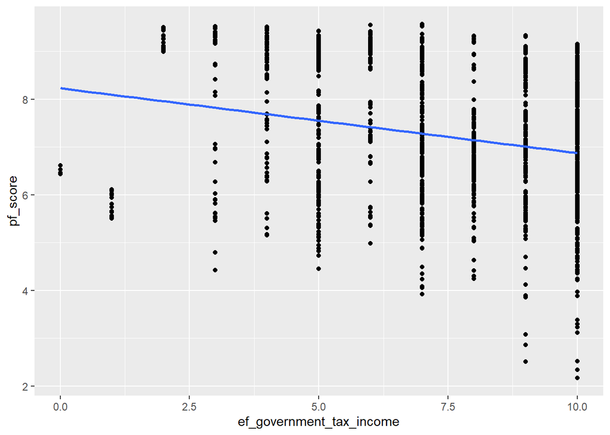

```r
ggplot(data = hfi, aes(x = ef_government_tax_income, y = pf_score)) +
  geom_point() +
  stat_smooth(method = "lm", se = FALSE)
```

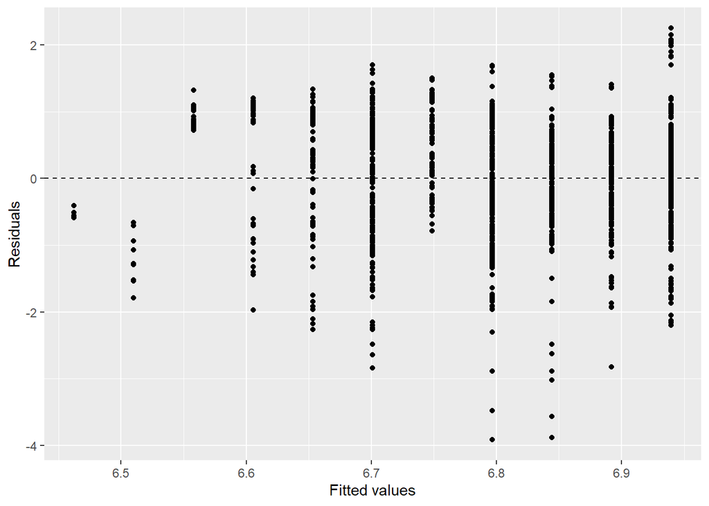

```r
ggplot(data = m4, aes(x = .fitted, y = .resid)) +
  geom_point() +
  geom_hline(yintercept = 0, linetype = "dashed") +
  xlab("Fitted values") +
  ylab("Residuals")
```

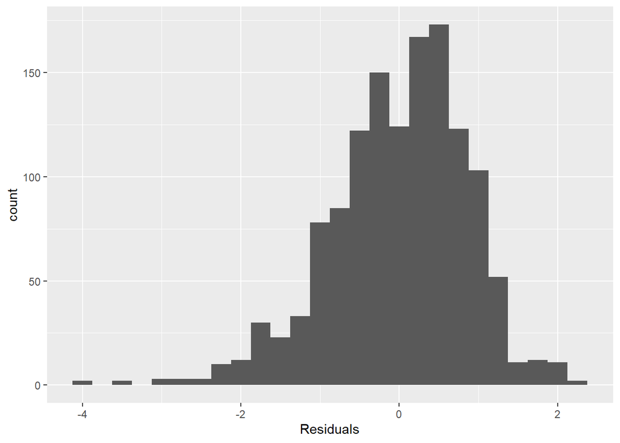

```r
ggplot(data = m4, aes(x = .resid)) +
  geom_histogram(binwidth = 0.25) +
  xlab("Residuals")
```